# Milestone #6

Rachael Baartmans, Lara Petalio, Christine Truong

2022-12-11

## Problem Statement

We aimed to investigate how tobacco use primarily impacts mental illness among smokers in California in 2011 and explore how race and location of cigarette purchase can impact disease status. We were also interested in utilizing the 2011 CSC data to help us understand tobacco consumption in terms of “pack-years,” which is the product of the number of packs of cigarettes smoked per day and the years a person has smoked, and comparing the average number of pack-years to asthma, heart disease, diabetes, and mental illness. Based on our observations from our analyses, we hope to provide some insight and suggestions for CDPH on how to redirect resources that can strengthen smoking cessation strategies from this project.

## Methods

#### **Data Source**

Sponsored by the State of California’s Department of Public Health (CDPH), the data source for this project is the 2011 California Smokers Cohort (CSC), which is a part of the California Tobacco Surveys (CTS) that collected information on the prevalence of tobacco use in California and behaviors among smokers in order to inform tobacco prevention efforts. To help CDPH better assess the effectiveness of smoking cessation strategies, the 2011 CSC data specifically investigates characters associated with quitting behavior among only smokers identified through telephone contacts purchased from data brokers, as well as through the California Health Interview Survey Longitudinal Smokers Survey (CLSS) between July 8, 2011 and December 8, 2011. This data from the surveys conducted were split into two separate data sets, with the first containing information regarding each participant’s smoking status, behaviors associated with smoking, and demographics; the second data set includes information regarding each participant’s race and disease outcomes. The data sets were stored as data frames called `smoker_data` and `race_data`, respectively.

### **Data Wrangling**

#### **Cleaning the Data**

During the import of our data, we did not exclude any missing values and reclassified any response value of “(DO NOT READ)”/“n/a”/any variations of N/A as missing.

Following the importing stage, we changed the casing for all variables to lowercase in both data sets, re-coded some character values to be error free, and modified the “100 or more cigarettes” to “100” for the variable `howmany` in the `race_data` data frame. This allowed us to convert the data type of the variable from character to numeric; the purpose of this conversion was to facilitate our calculation for pack-years later on in our analysis.

To join the two data frames we re-coded the values of the variable `id` in the `race_data` data frame to show only numbers and no character strings. This was done so the values of `id` would match those of the variable `psraid` in the `smoker_data` data frame since they both represent participant IDs. We then converted the data type of `psraid` from numeric to character; with the same data type for the identical key variables of `id` = `psraid`, we were then able to join the two data sets together into a single data frame.

#### **Creating New Variables**

Our group created a new variable called `race` to combine variables `race01` through `race15` into a single column shown in our final joined data frame for better comprehension of the race of each individual in our data set at first glance.We also created was `pack_years`, which was created by multiplying the number of cigarette packs per day by the length of time a participant has been smoking on a daily basis.

#### **Additional Data Wrangling for Visualizations**

For all of our visualizations, we dropped all missing values based on variables presented in tables and graphs because we found these missing values to be unhelpful toward our analysis of the data.

## Results

### **Table 1**

| Disease | Average Number of Pack-years |
| --- | --- |
| Asthma | 25 |
| Diabetes | 25 |
| Heart Disease | 28 |
| Mental Illness | 17 |

Data Source: 2011 California Smokers Cohort, CA Dept. of Health

This table demonstrates the average number of pack-years per disease type for smokers who reported having asthma, diabetes, heart disease, and/or mental illness in the 2011 California Smokers Cohort study.

Among smokers who have reported having asthma, heart disease, diabetes, and/or mental illness, those with heart disease have the highest number of average pack-years (28), while those with mental illness have the lowest number of average pack-years (17).

### **Table 2**

| Race | No Mental Illness | Has Mental Illness | Percentage With Mental Illness (%) |
| --- | --- | --- | --- |
| Don’t know | 1 | 1 | 50.0 |
| Refused | 4 | 3 | 42.9 |
| Other | 2 | 1 | 33.3 |
| American Indian or Alaskan Native | 29 | 10 | 25.6 |
| Filipino | 6 | 2 | 25.0 |
| White | 660 | 137 | 17.2 |
| Black | 64 | 13 | 16.9 |
| Other Asian or Pacific Islander | 5 | 1 | 16.7 |
| Mexican | 17 | 2 | 10.5 |
| Hispanic/Latino | 16 | 1 | 5.9 |
| Asian Indian | 1 | NA | NA |
| Chinese | 7 | NA | NA |
| Japanese | 6 | NA | NA |
| Vietnamese | 2 | NA | NA |

Data Source: 2011 California Smokers Cohort, CA Dept. of Health

This table displays the number and percentage of participants who reported having mental illness, as well as the number of participants who reported having no mental illness, stratified by racial background of the participants.

Participants who responded with “Don’t know” to their racial identification appear to have the greatest percentage of mental illness, followed by those who refused to state their racial identification; with these non-informative exceptions, those who identified as “Other” appear to have the greatest percentage of mental illness (33.3%), followed by “American Indian or Alaskan Native” (25.6%).

### **Figure 1**

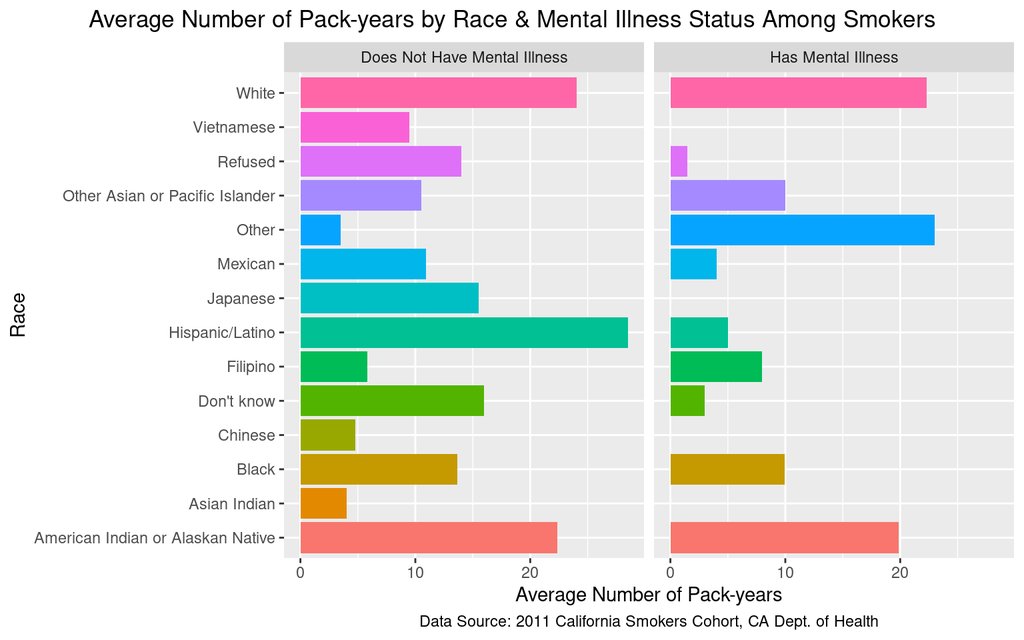

This graph exhibits the number of average pack-years for each race category and by reported mental illness status of smokers in the 2011 California Smokers Cohort study.

Among smokers who have reported having no mental illness, those who identified as “Hispanic/Latino” by race appear to have the greatest number of average pack-years, followed by “White” and “American Indian or Alaskan Native,” out of all race categories in the 2011 California Smokers Cohort.

Among smokers who have reported having mental illness, those who identified as “Other” by race appear to have the greatest number of average pack-years compared to other races in the 2011 California Smokers Cohort, with “White” and “American Indian or Alaskan Native” following closely behind.

### **Figure 2**

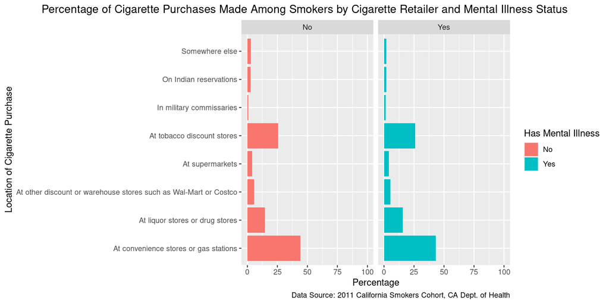

This bar graph explores the relationship between cigarette purchase location frequencies by smokers and reported mental illness status among smokers in the 2011 California Smokers Cohort study.

Among smokers with reported mental illness, the greatest percentage of cigarette purchases were made at convenience stores or gas stations, followed by the location of tobacco discount stores; these are the two locations that also have the highest percentages for buying cigarettes at among smokers with no reported mental illness.

## Discussion

Based on our results from the analysis of our data, the impact of race on mental illness status is inconclusive. This conclusion is supported by the semi-conflicting information given by Table 2 and Figure 1; with the exception of the two non-informative race category responses of “Don’t know” and “Refused” in Table 2, smokers who identified as “Other” appear to have the greatest percentage of mental illness cases, followed by smokers who identified as “American Indian or Alaskan Native.” Among smokers who reported having mental illness in Figure 1, those who identified as “Other” had the greatest average number of pack-years, but those who identified as “White” followed more closely behind in average number of pack-years than those who identified as “American Indian or Alaskan Native,” which also had a significant average number of pack-years compared to other race categories. The observation of the “White” race category having a greater average number of pack-years than “American Indian or Alaskan Native” among smokers with reported mental illness in Figure 1 is thus notable because it disrupts the slight trend we see in both Table 2 and Figure 1 of the “Other” and “American Indian or Alaskan Native” race categories having an association with mental illness among smokers. This interesting observation warrants further research into the relationship between race and reported mental illness outcomes, with the recommendation that potential confounders and sources of potential bias are accounted for, which were not in this analysis. For example, given the data we have here, we do not know how accurate participants’ reports of diagnosed mental illnesses are, which may skew the length of the bars per race by reported mental illness status category in Figure 1.

Lastly, we conclude that out of the four diseases of asthma, diabetes, heart disease, and mental illness, tobacco consumption in terms of pack-years was the lowest among smokers who reported having mental illness and the highest among smokers who reported having heart disease; this conclusion is supported by the information exhibited in Table 1.

Overall, our group recommends that CDPH further investigate the cigarette purchasing locations of convenience stores, gas stations, and tobacco discount stores and their relationship to mental illness diagnoses. CDPH could look into potential tobacco product(s) specifically sold at these locations that smokers cannot get anywhere else, as well as the potency of the specific product(s). In addition, we recommend CDPH to look into the unique characteristics of the demographic that frequent these places. The findings of these investigations could then lead to more concrete conclusions of our group’s analyses in order to further develop tobacco cessation programs and interventions. If financial budgets permit, CDPH could additionally conduct further studies on the impact of race on mental illness outcomes, possibly with different methods to measure the outcomes of mental illness instead of relying on participant reporting that would minimize bias in order to arrive at more concrete conclusions.